# Game of Thrones Sentiment Analysis

created on 6 October 2023 and updated 10 October, 2023

Getting the GoT data:

```r
got_path <- here("data","got.pdf")
got_text <- pdf_text(got_path)
```

## Some wrangling:

- Split up pages into separate lines (separated by ) using stringr::str_split()
- Unnest into regular columns using tidyr::unnest()
- Remove leading/trailing white space with stringr::str_trim()

```r
got_df <- data.frame(got_text) %>%
  mutate(text_full = str_split(got_text, pattern = '\n')) %>%
  unnest(text_full) %>%
  mutate(text_full = str_trim(text_full))
```

Now each line, on each page, is its own row, with extra starting & trailing spaces removed.

## Get the tokens (individual words) in tidy format

Use tidytext::unnest_tokens() (which pulls from the tokenizer) package, to split columns into tokens. We are interested in words, so that’s the token we’ll use:

```r
got_tokens <- got_df %>%
  unnest_tokens(word, text_full)
```

Counting the words:

```r
got_wc <- got_tokens %>%
  count(word) %>%
  arrange(-n)
got_wc
```

```
## # A tibble: 11,826 × 2
##    word      n
##    <chr> <int>
##  1 the   17988
##  2 and    8997
##  3 to     6640
##  4 a      6461
##  5 of     6200
##  6 he     5166
##  7 his    5161
##  8 was    3904
##  9 her    3659
## 10 you    3267
## # ℹ 11,816 more rows
```

## Remove stop words:

See ?stop_words and View(stop_words)to look at documentation for stop words lexicons.

We will remove stop words using tidyr::anti_join():

```r
got_stop <- got_tokens %>%
  anti_join(stop_words) %>%
  select(-got_text)
```

Checking counts again:

```r
got_swc <- got_stop %>%
  count(word) %>%
  arrange(-n)
got_swc
```

```
## # A tibble: 11,295 × 2
##    word       n
##    <chr>  <int>
##  1 lord    1341
##  2 ser     1023
##  3 jon      787
##  4 ned      743
##  5 tyrion   591
##  6 eyes     567
##  7 hand     567
##  8 king     542
##  9 father   512
## 10 told     504
## # ℹ 11,285 more rows
```

getting rid of all the numbers (non-text) in got_stop:

```r
# This code will filter out numbers by asking:
# If you convert to as.numeric, is it NA (meaning those words)?
# If it IS NA (is.na), then keep it (so all words are kept)
# Anything that is converted to a number is removed

got_no_numeric <- got_stop %>%
  filter(is.na(as.numeric(word)))
```

Unique words:

```r
length(unique(got_no_numeric$word))
```

```
## [1] 11209
```

```r
got_top120 <- got_no_numeric %>%
  count(word) %>%
  arrange(-n) %>%
  head(120)
```

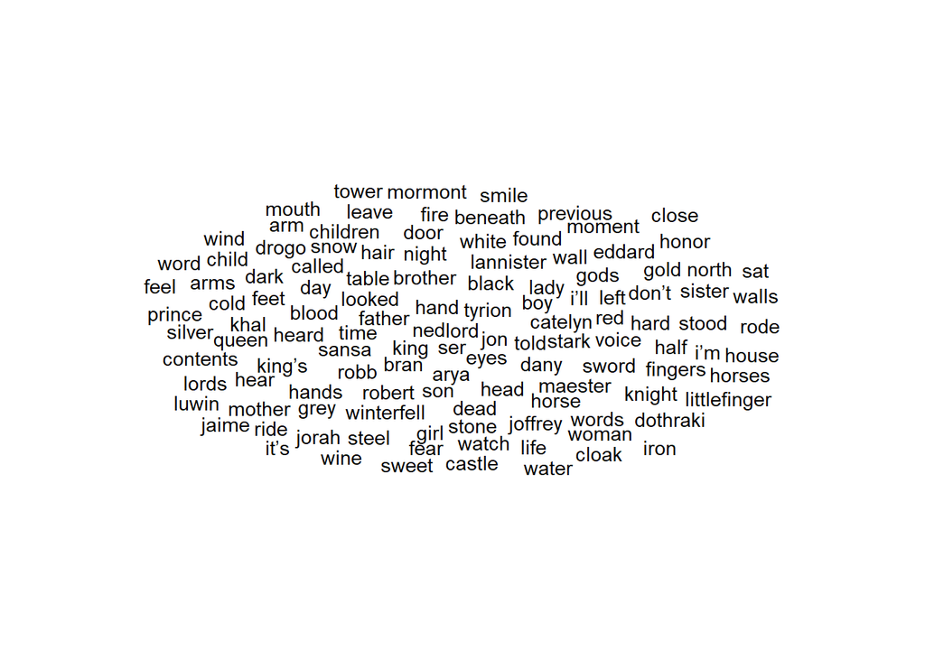

```r
got_cloud <- ggplot(data = got_top120, aes(label = word)) +
  geom_text_wordcloud() +
  theme_minimal()

got_cloud
```

Let’s customize it:

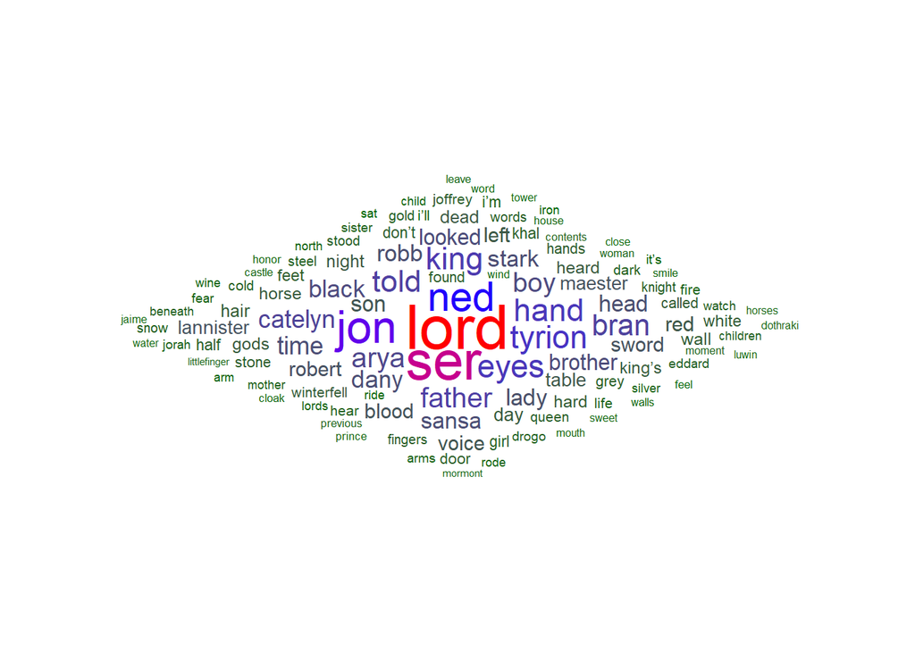

```r
ggplot(data = got_top120, aes(label = word, size = n)) +
  geom_text_wordcloud_area(aes(color = n), shape = "diamond") +
  scale_size_area(max_size = 12) +
  scale_color_gradientn(colors = c("darkgreen","blue","red")) +
  theme_minimal()
```

## Sentiment analysis

Loading the “AFINN” sentiments:

```r
get_sentiments(lexicon = "afinn")
```

```
## # A tibble: 2,477 × 2
##    word       value
##    <chr>      <dbl>
##  1 abandon       -2
##  2 abandoned     -2
##  3 abandons      -2
##  4 abducted      -2
##  5 abduction     -2
##  6 abductions    -2
##  7 abhor         -3
##  8 abhorred      -3
##  9 abhorrent     -3
## 10 abhors        -3
## # ℹ 2,467 more rows
```

Let’s look at the most positive words:

```r
afinn_pos <- get_sentiments("afinn") %>%
  filter(value %in% c(5))
afinn_pos
```

```
## # A tibble: 5 × 2
##   word         value
##   <chr>        <dbl>
## 1 breathtaking     5
## 2 hurrah           5
## 3 outstanding      5
## 4 superb           5
## 5 thrilled         5
```

Loading “Bing” sentiments:

```r
get_sentiments(lexicon = "bing")
```

```
## # A tibble: 6,786 × 2
##    word        sentiment
##    <chr>       <chr>
##  1 2-faces     negative
##  2 abnormal    negative
##  3 abolish     negative
##  4 abominable  negative
##  5 abominably  negative
##  6 abominate   negative
##  7 abomination negative
##  8 abort       negative
##  9 aborted     negative
## 10 aborts      negative
## # ℹ 6,776 more rows
```

loading “nrc”:

```r
get_sentiments(lexicon = "nrc")
```

```
## # A tibble: 13,872 × 2
##    word        sentiment
##    <chr>       <chr>
##  1 abacus      trust
##  2 abandon     fear
##  3 abandon     negative
##  4 abandon     sadness
##  5 abandoned   anger
##  6 abandoned   fear
##  7 abandoned   negative
##  8 abandoned   sadness
##  9 abandonment anger
## 10 abandonment fear
## # ℹ 13,862 more rows
```

## Sentiment analysis with afinn

First, binding words in got_stop to afinn lexicon:

```r
got_afinn <- got_stop %>%
  inner_join(get_sentiments("afinn"))
```

Let’s find some counts (by sentiment ranking):

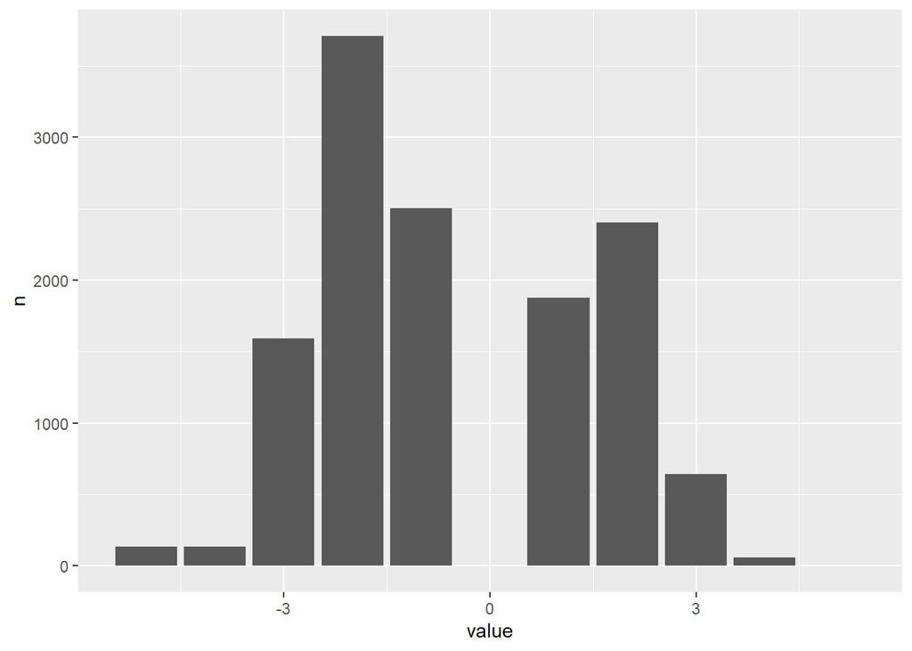

```r
got_afinn_hist <- got_afinn %>%
  count(value)

# Plot them:
ggplot(data = got_afinn_hist, aes(x = value, y = n)) +
  geom_col()
```

the -5 observations are probably almost all from the word “bastard” (meaning born outside of marriage) which is used quite a lot in GoT, especially when they talk about/to Jon, which we saw earlier is the person most often mentioned.

Investigate some of the words in a bit more depth: let’s see if what I just hypothesized is true:

```r
got_afinn %>%
  filter(value == -5) %>%
  group_by(word) %>%
  count()
```

```
## # A tibble: 6 × 2
## # Groups:   word [6]
##   word         n
##   <chr>    <int>
## 1 bastard     88
## 2 bastards    30
## 3 bitch        9
## 4 cock         4
## 5 cunt         1
## 6 slut         5
```

Hey, I was right :)

What are these ‘4’ words? Let’s count them:

```r
got_afinn4 <- got_afinn %>%
  filter(value == 4)
got_afinn4
```

```
## # A tibble: 57 × 2
##    word    value
##    <chr>   <dbl>
##  1 win         4
##  2 winning     4
##  3 win         4
##  4 fun         4
##  5 funny       4
##  6 funny       4
##  7 fun         4
##  8 winner      4
##  9 win         4
## 10 fun         4
## # ℹ 47 more rows
```

And plot them:

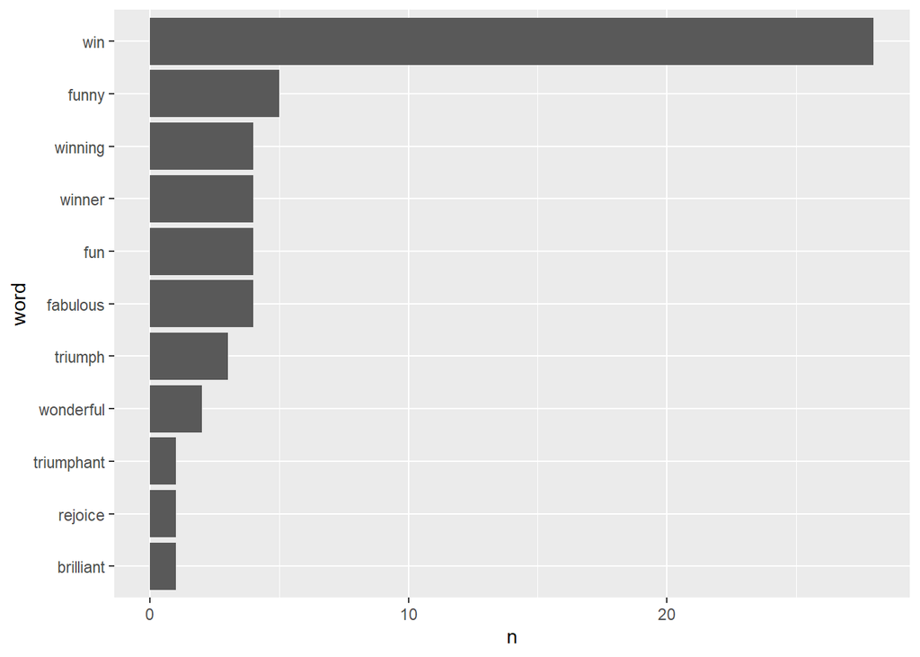

```r
got_afinn4_n <- got_afinn4 %>%
  count(word, sort = TRUE) %>%
  mutate(word = fct_reorder(factor(word), n))

ggplot(data = got_afinn4_n, aes(x = word, y = n)) +
  geom_col() +
  coord_flip()
```

Let’s do the same for “1”-valued words:

```r
got_afinn1 <- got_afinn %>%
  filter(value == 1)
got_afinn1
```

```
## # A tibble: 1,875 × 2
##    word     value
##    <chr>    <dbl>
##  1 shared       1
##  2 laughed      1
##  3 safety       1
##  4 feeling      1
##  5 share        1
##  6 huge         1
##  7 prepared     1
##  8 shared       1
##  9 laugh        1
## 10 laughed      1
## # ℹ 1,865 more rows
```

We’re going to have to use head() to show only the top occurring words (there are too many to show visually).

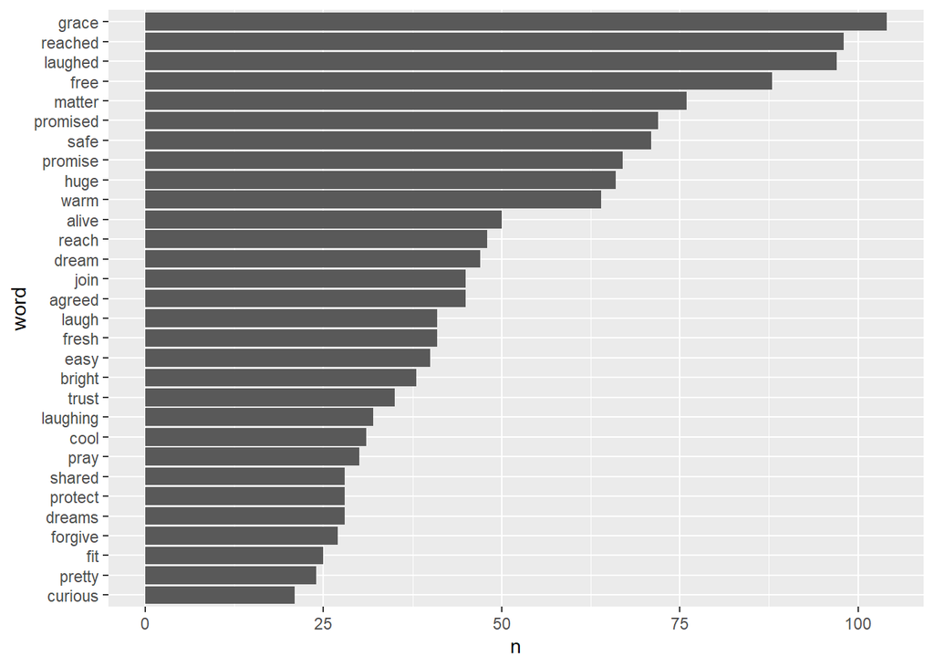

```r
got_afinn1_n <- got_afinn1 %>%
  count(word, sort = TRUE) %>%
  mutate(word = fct_reorder(factor(word), n)) %>%
  head(30)

ggplot(data = got_afinn1_n, aes(x = word, y = n)) +
  geom_col() +
  coord_flip()
```

We can summarize sentiment for the book:

```r
got_summary <- got_afinn %>%
  summarize(
    mean_score = mean(value),
    median_score = median(value)
  )
got_summary
```

```
## # A tibble: 1 × 2
##   mean_score median_score
##        <dbl>        <dbl>
## 1     -0.542           -1
```

The book tends to use more negative words.

## NRC lexicon for sentiment analysis

```r
got_nrc <- got_stop %>%
  inner_join(get_sentiments("nrc"))
```

A lot of the words used in GoT is not going to be included in this sentiment package, since they are names or very odd words such as the use of “ser” instead of “sir”.

Checking which words are excluded:

```r
got_exclude <- got_stop %>%
  anti_join(get_sentiments("nrc"))
# Count to find the most excluded:
got_exclude_n <- got_exclude %>%
  count(word, sort = TRUE)

head(got_exclude_n)
```

```
## # A tibble: 6 × 2
##   word       n
##   <chr>  <int>
## 1 ser     1023
## 2 jon      787
## 3 ned      743
## 4 tyrion   591
## 5 eyes     567
## 6 hand     567
```

Now some counts:

```r
got_nrc_n <- got_nrc %>%
  count(sentiment, sort = TRUE)
```

And plotting them:

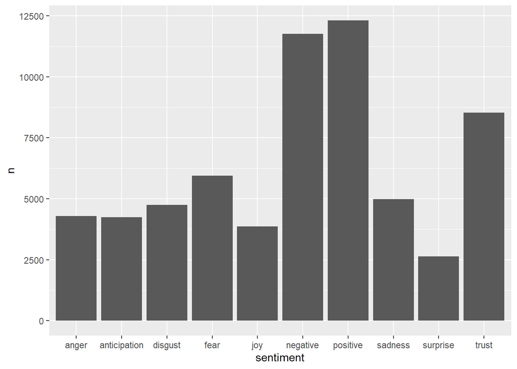

```r
ggplot(data = got_nrc_n, aes(x = sentiment, y = n)) +
  geom_col()
```

Or count by sentiment and word, then facet:

```r
got_nrc_n5 <- got_nrc %>%
  count(word,sentiment, sort = TRUE) %>%
  group_by(sentiment) %>%
  top_n(5) %>%
  ungroup()
```

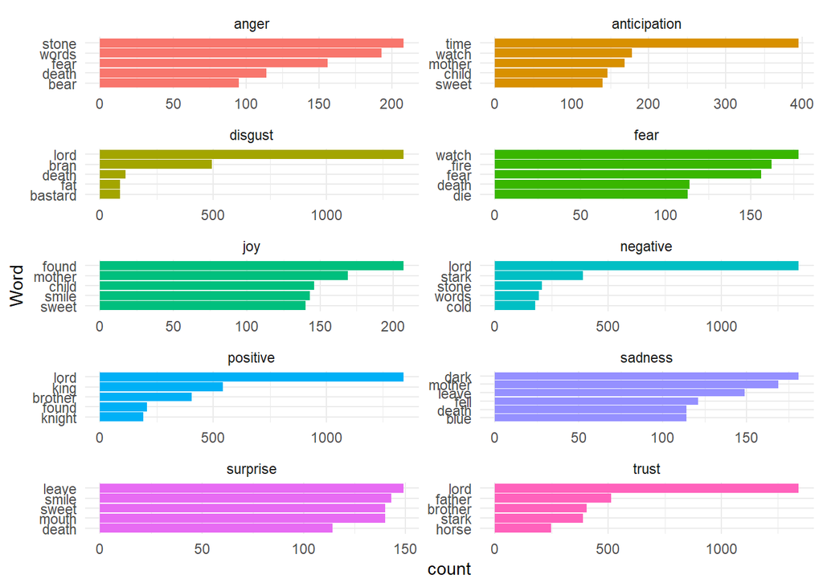

```r
got_nrc_gg <- ggplot(data = got_nrc_n5, aes(x = reorder(word,n), y = n, fill = sentiment)) +
  geom_col(show.legend = FALSE) +
  facet_wrap(~sentiment, ncol = 2, scales = "free") +
  coord_flip() +
  theme_minimal() +
  labs(x = "Word", y = "count")

got_nrc_gg
```

saving it:

```r
ggsave(plot = got_nrc_gg,
       here("figures","got_nrc_sentiment.png"),
       height = 8,
       width = 5)
```